# Påvirker høyden inntekten?

Sofie Brynjelsen

Silje Marie Danielsen

# Introduksjon

I denne oppgaven vil vi i hovedsak se på om høyde påvirker inntekten. For å finne ut dette har vi tatt i bruk studien/datasettet kalt *heights* fra R pakken *modelr*. Vi har også sett på andre variabler som kjønn og sivilstatus, for å finne ut om disse faktorene har en påvirkning på inntekten.

# Statistikk

```
##      sex           income             height         weight
##  male  :3402   Min.   :     0.0   Min.   :52.0   Min.   : 76.0
##  female:3604   1st Qu.:   165.5   1st Qu.:64.0   1st Qu.:157.0
##                Median : 29589.5   Median :67.0   Median :184.0
##                Mean   : 41203.9   Mean   :67.1   Mean   :188.3
##                3rd Qu.: 55000.0   3rd Qu.:70.0   3rd Qu.:212.0
##                Max.   :343830.0   Max.   :84.0   Max.   :524.0
##                                                  NA's   :95
##       age
##  Min.   :47.00
##  1st Qu.:49.00
##  Median :51.00
##  Mean   :51.33
##  3rd Qu.:53.00
##  Max.   :56.00
##
```

```
##       marital         sex         education          afqt
##  single   :1124   male  :3402   Min.   : 1.00   Min.   :  0.00
##  married  :3806   female:3604   1st Qu.:12.00   1st Qu.: 15.12
##  separated: 366                 Median :12.00   Median : 36.76
##  divorced :1549                 Mean   :13.22   Mean   : 41.21
##  widowed  : 161                 3rd Qu.:15.00   3rd Qu.: 65.24
##                                 Max.   :20.00   Max.   :100.00
##                                 NA's   :10      NA's   :262
##     heightIntSex
##  svært lav:1967
##  lav      :1365
##  middels  :1379
##  høy      :1213
##  svært høy:1082
##
##
```

Vi velger å legge hovedvekt på sammenhengen mellom høyde og inntekt, samt se om sivilstatus og kjønn har en påvirking på inntekt. Det er 3402 menn og 3604 kvinner som deltok i undersøkelsen. I kolonnen inntekt er gjennomsnittet relativt høyt forhold til medianen. En forklaring på dette kan være at det er noen som tjener veldig mye. Dette øker gjennomsnittet, men ikke meridianen.

# Plots

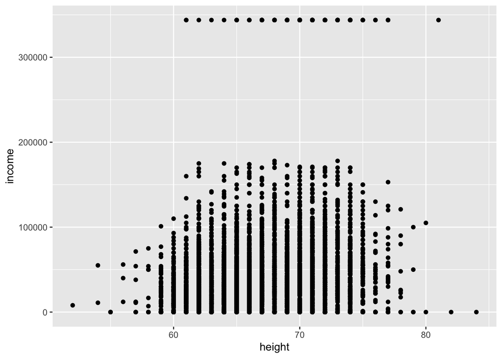

Her ser vi sammenhengen mellom høyde og inntekt. De ulike prikkene illustrerer observasjonenen til studien som er blitt tatt. De øverste prikkene er de som har høyest lønn. Observasjonen øverst i diagrammet illustrerer gjennomsnittslønnen til de som ligger på et veldig høyt lønnsnivå.

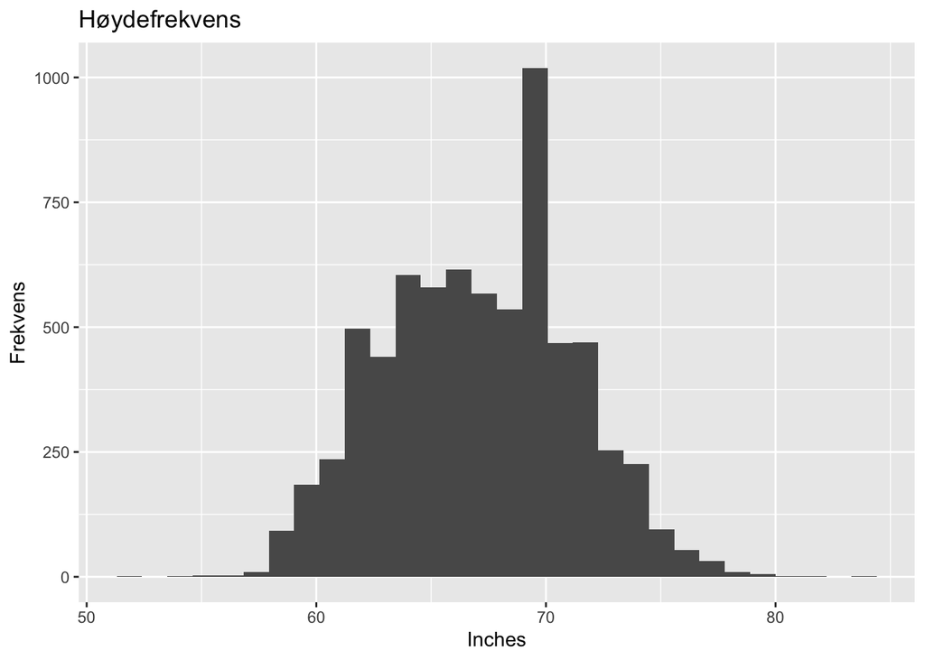

# Desnity plot

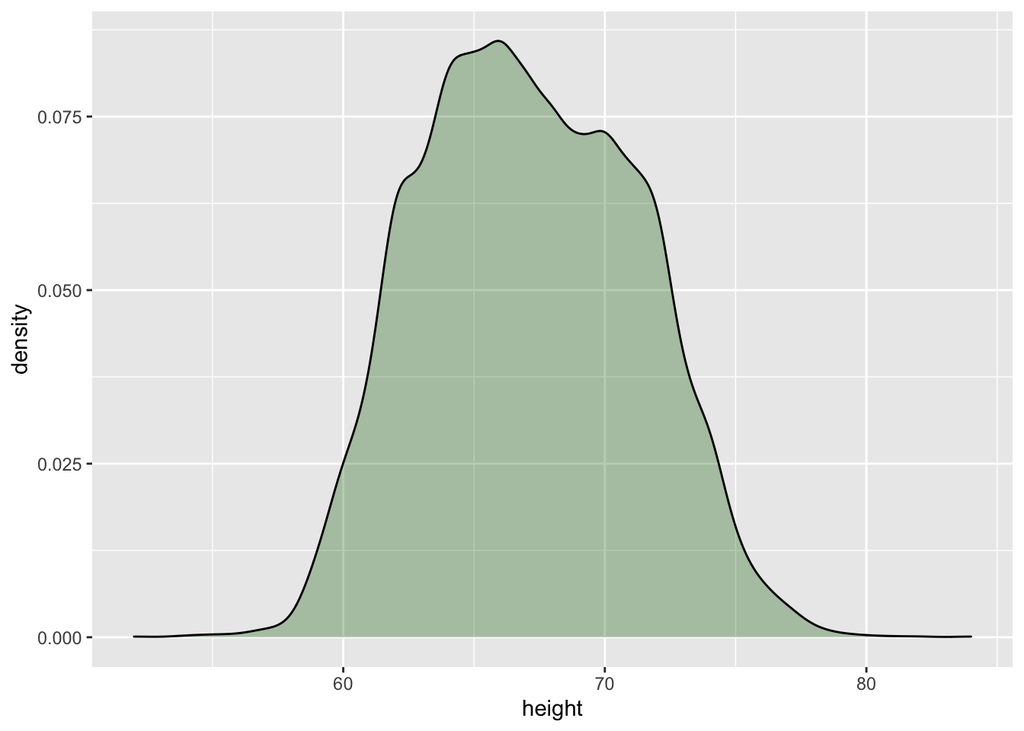

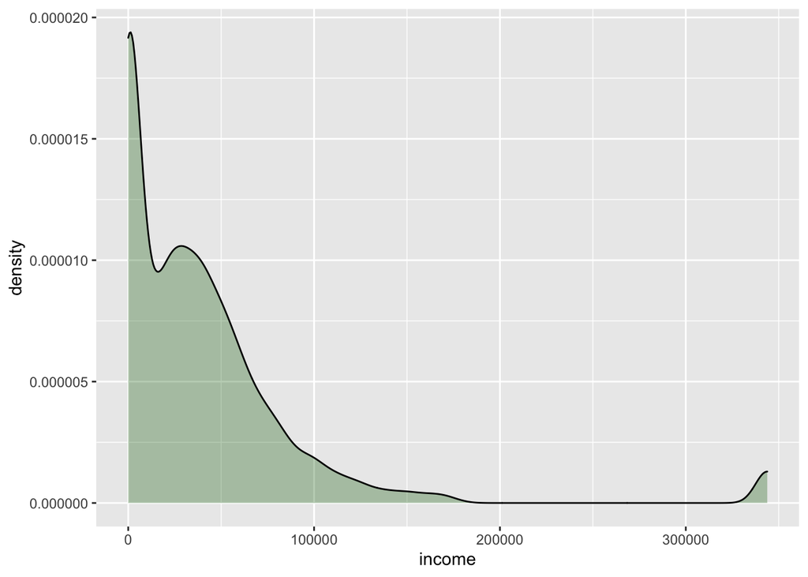

Videre ville vi se på variabelen inntekt i et density plot. Vi ser at denne neppe er normalfordelt.

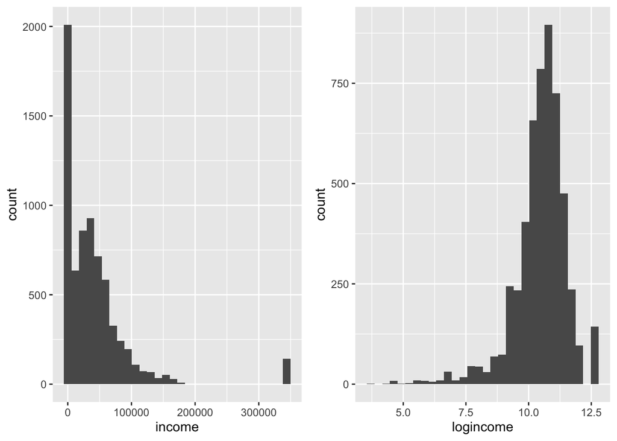

Ettersom inntekt ikke var normalfordelt, har vi nå valgt å foreta en transformasjon.

# Sammenligning av menn og kvinner

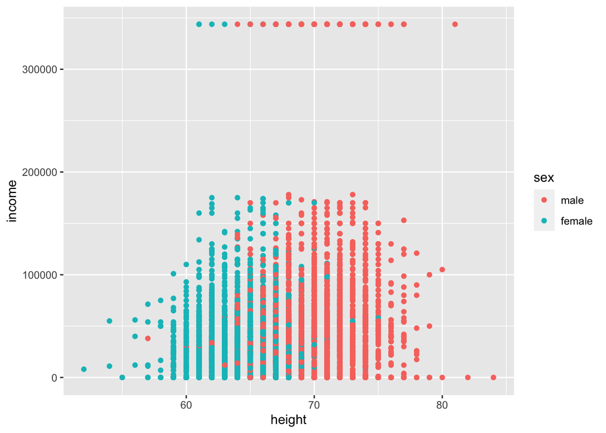

I dette plottet har vi delt opp variablene høyde og inntekt for gruppene kvinner og menn. Kjønn er kodet med farge, mens observasjonens plassering angir verdien for høyde og inntekt. Man kan se at der er flest menn på punktene øverst i plottet og at det er de som har høyest lønn.

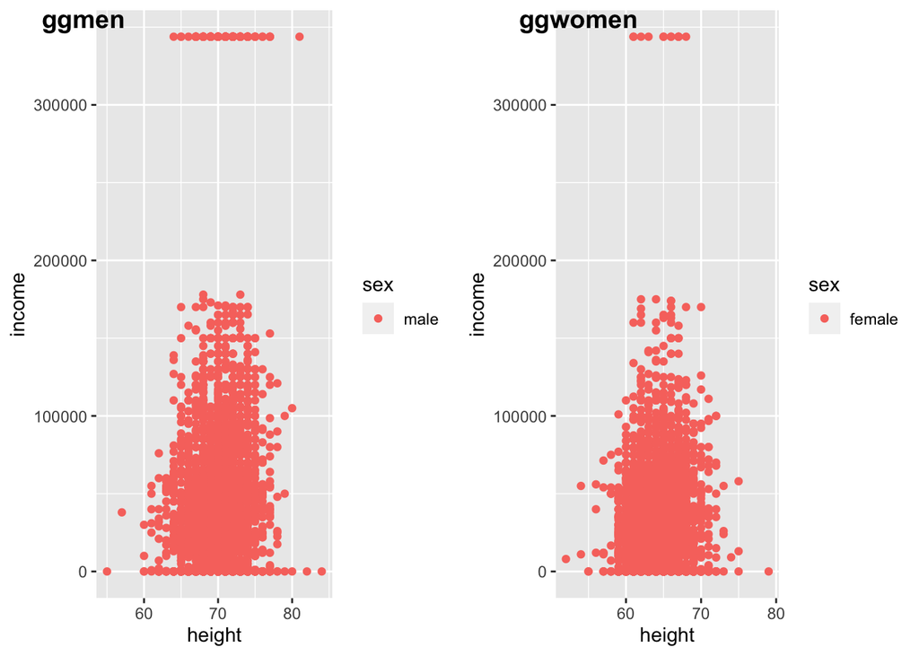

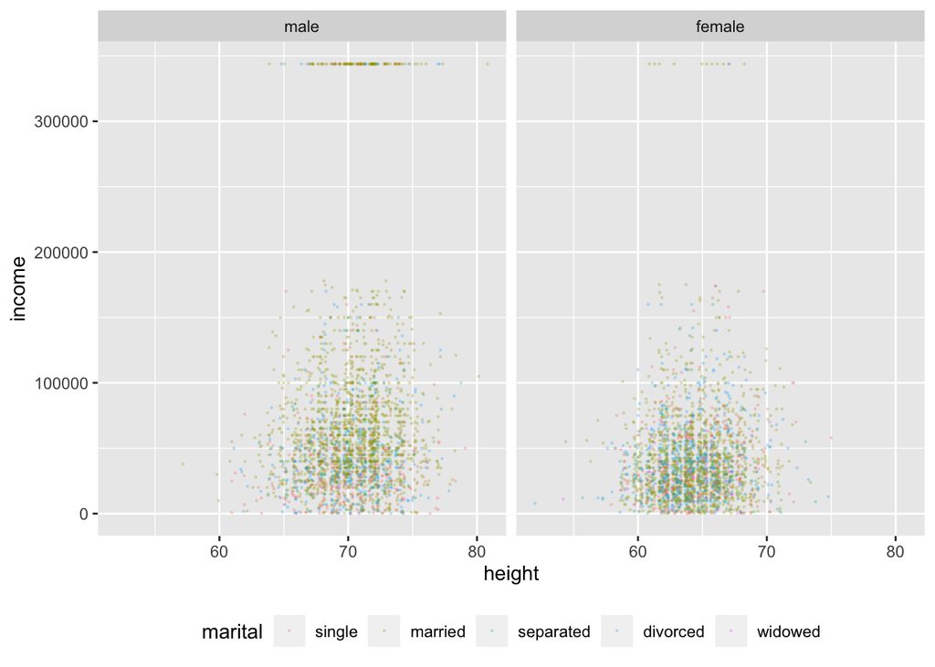

I graf ggmen, er det flest menn i høyden 65 til 74. **år, inches, hva? - Forklar** Ser på grafen til høyre ser vi at flertallet av kvinner har en høyde på 60 til 70. **år, inches, hva? - Forklar** Man kan også se at det er flere menn enn kvinner som har høy inntekt.

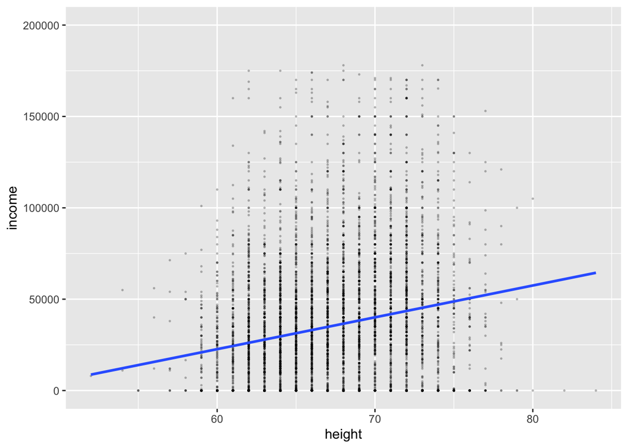

Her ser vi at høyde har en positiv korrelasjon med inntekt.

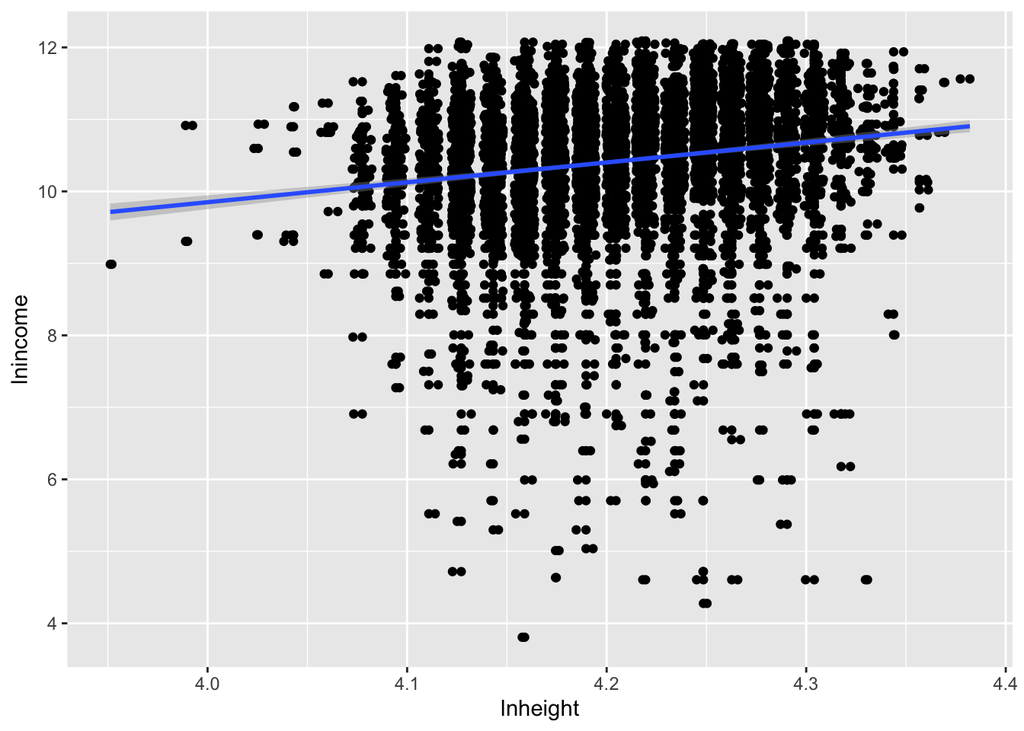

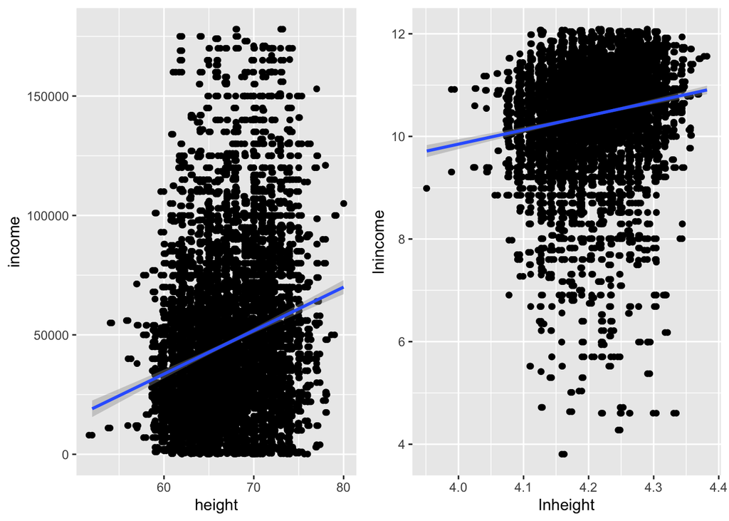

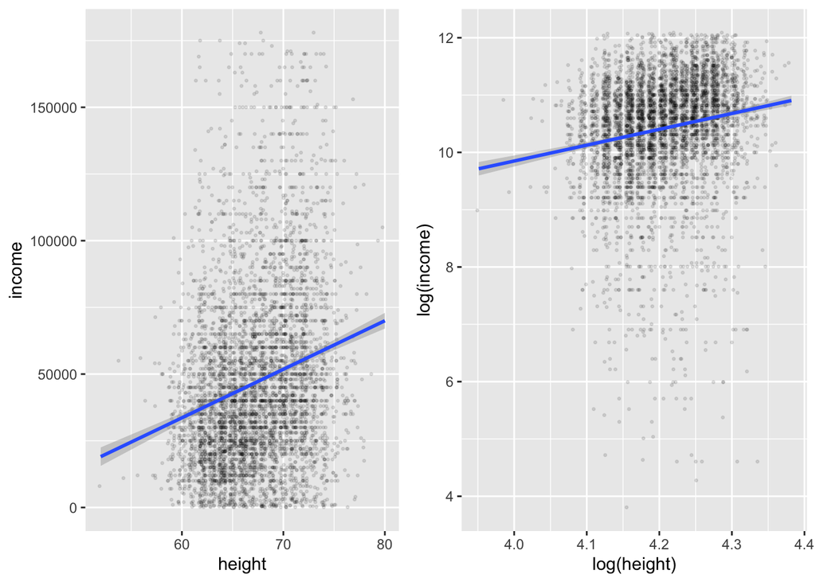

```
##
## Call:
## lm(formula = income ~ height, data = .)
##
## Residuals:
##    Min     1Q Median     3Q    Max
## -91583 -31511 -10893  14882 320828
##
## Coefficients:
##              Estimate Std. Error t value Pr(>|t|)
## (Intercept) -158888.1    10733.8  -14.80   <2e-16 ***
## height         2981.8      159.7   18.68   <2e-16 ***
## ---
## Signif. codes:  0 '***' 0.001 '**' 0.01 '*' 0.05 '.' 0.1 ' ' 1
##
## Residual standard error: 54550 on 7004 degrees of freedom
## Multiple R-squared:  0.04744,    Adjusted R-squared:  0.0473
## F-statistic: 348.8 on 1 and 7004 DF,  p-value: < 2.2e-16
```

```
##
## Call:
## lm(formula = I(log(income)) ~ I(log(height)), data = .)
##
## Residuals:
##     Min      1Q  Median      3Q     Max
## -6.5056 -0.4022  0.1250  0.5999  2.6033
##
## Coefficients:
##                Estimate Std. Error t value  Pr(>|t|)
## (Intercept)     -4.2183     0.9960  -4.235 0.0000232 ***
## I(log(height))   3.4939     0.2367  14.761   < 2e-16 ***
## ---
## Signif. codes:  0 '***' 0.001 '**' 0.01 '*' 0.05 '.' 0.1 ' ' 1
##
## Residual standard error: 1.036 on 5264 degrees of freedom
## Multiple R-squared:  0.03975,    Adjusted R-squared:  0.03957
## F-statistic: 217.9 on 1 and 5264 DF,  p-value: < 2.2e-16
```

Den til høyre illustrerer prosentandel.

**Prosentandel av hva?**

Hvor mange prosent inntekten øker med hvis vi øker høyden med 1%.

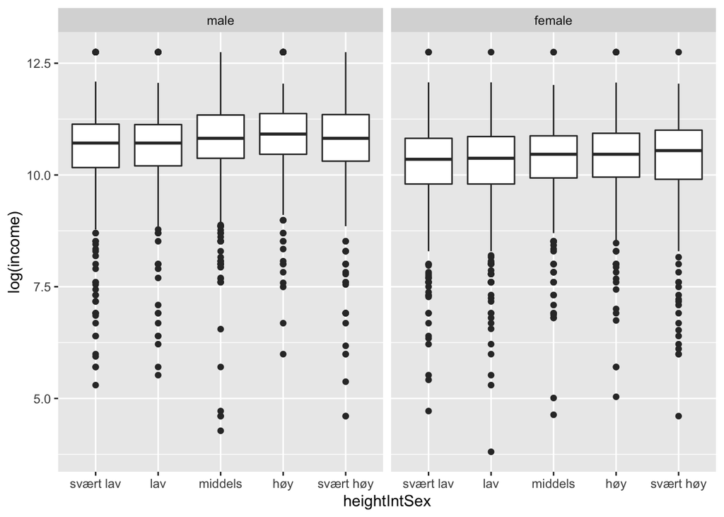

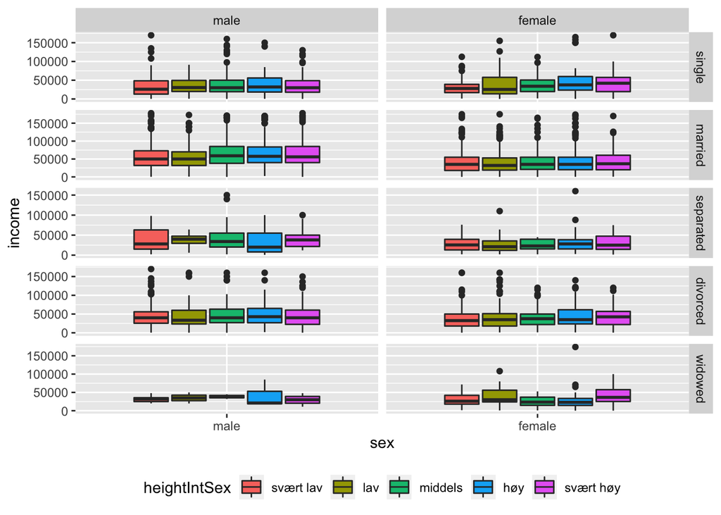

Hvis vi sammenligner de to boxene kan vi se at mange av de som ligger høyt på inntekt er gift, men det er en jevn spredning.

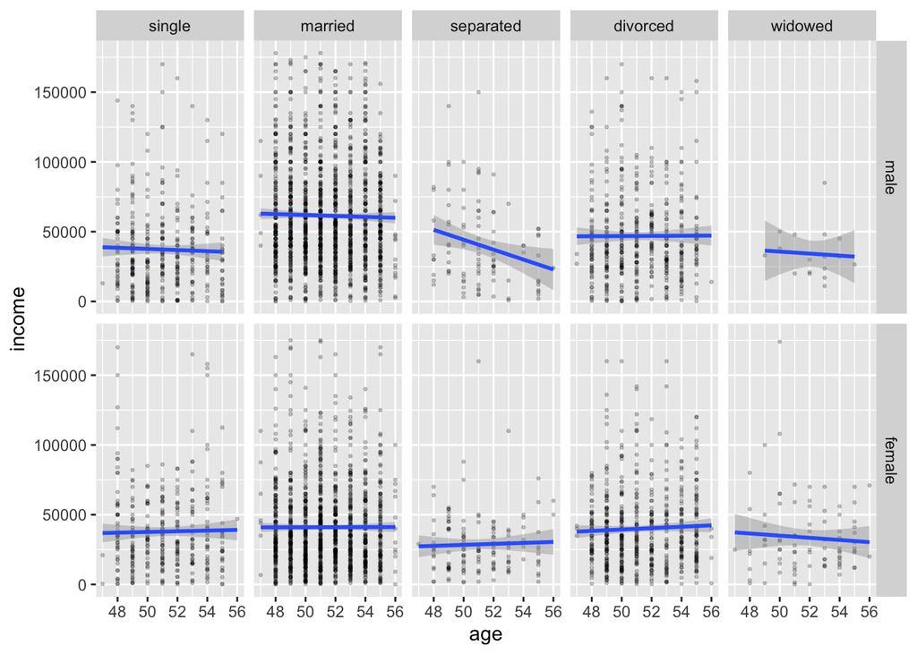

## Høyinntekstgruppen

Dere bør også si litt om høyinnteksgruppen.

| marital | sex | n() |
| --- | --- | --- |
| single | male | 10 |
| single | female | 1 |
| married | male | 108 |
| married | female | 10 |
| divorced | male | 12 |
| divorced | female | 1 |
| widowed | male | 1 |

Ser ut til at de fleste med høy inntekt er gift.

| sex | heightIntSex | n() |
| --- | --- | --- |
| male | svært lav | 20 |
| male | lav | 14 |
| male | middels | 42 |
| male | høy | 24 |
| male | svært høy | 31 |
| female | svært lav | 3 |
| female | lav | 1 |
| female | middels | 2 |
| female | høy | 5 |
| female | svært høy | 1 |

# Resultater

```
##
## Call:
## lm(formula = income ~ height, data = heights)
##
## Residuals:
##    Min     1Q Median     3Q    Max
## -91583 -31511 -10893  14882 320828
##
## Coefficients:
##              Estimate Std. Error t value Pr(>|t|)
## (Intercept) -158888.1    10733.8  -14.80   <2e-16 ***
## height         2981.8      159.7   18.68   <2e-16 ***
## ---
## Signif. codes:  0 '***' 0.001 '**' 0.01 '*' 0.05 '.' 0.1 ' ' 1
##
## Residual standard error: 54550 on 7004 degrees of freedom
## Multiple R-squared:  0.04744,    Adjusted R-squared:  0.0473
## F-statistic: 348.8 on 1 and 7004 DF,  p-value: < 2.2e-16
```

```
##
## Call:
## lm(formula = income ~ sex + height + education, data = heights)
##
## Residuals:
##     Min      1Q  Median      3Q     Max
## -117414  -25914   -6420   14990  328518
##
## Coefficients:
##              Estimate Std. Error t value Pr(>|t|)
## (Intercept) -102186.4    14603.7  -6.997 2.85e-12 ***
## sexfemale    -23200.8     1715.5 -13.524  < 2e-16 ***
## height          606.4      210.1   2.886  0.00391 **
## education      8675.6      231.4  37.499  < 2e-16 ***
## ---
## Signif. codes:  0 '***' 0.001 '**' 0.01 '*' 0.05 '.' 0.1 ' ' 1
##
## Residual standard error: 49620 on 6992 degrees of freedom
##   (10 observations deleted due to missingness)
## Multiple R-squared:  0.2127, Adjusted R-squared:  0.2124
## F-statistic: 629.7 on 3 and 6992 DF,  p-value: < 2.2e-16
```